# Data Analysis on Classifying the Severity of Genetic Mutations

[figure not shown]

By: Kelly Pleiman, Advisor: Dr. Chen

https://humantechnopole.it/en/research-centres/computational-biology/

# Overview

**The goal of my Capstone was to find a computational model to classify the severity of genetic mutations using the gene the mutation is on, the kind of variation, and the clinical evidence used to classify the mutation.**

Data Obtained From a Kaggle.com Research Prediction Competion Included:

1. Gene- the gene the genetic mutation was on (Ex. CBL, RUNX1)
2. Variation- shows the specific amino acid change that caused the muation (Ex. Q249E means glutamic acid (E) was placed as the amino acid in the 249 codon instead of glutamine (Q))
3. Text- clinical evidence in the form of text data

### Original Data

The original data came in two files:

1. `Variable data` on the gene, variation, and class for each mutations ID
2. `Text data` that the corresponds to each mutation ID

**Variable Data**

### Importing Data

Step one was using the pandas package to import the original variable data and text data into Jupyter Notebook.

**Variable Data Importation Code**

```python
import pandas as pd

#import the variable train data
trainVariants=pd.read_csv("training_variants.csv")

#display trainVariants
trainVariants.head()
```

|  | ID | Gene | Variation | Class |
| --- | --- | --- | --- | --- |
| 0 | 0 | FAM58A | Truncating Mutations | 1 |
| 1 | 1 | CBL | W802* | 2 |
| 2 | 2 | CBL | Q249E | 2 |
| 3 | 3 | CBL | N454D | 3 |
| 4 | 4 | CBL | L399V | 4 |

**Text Data Importation Code**

```python
#import the train text data file
trainText=pd.read_csv("training_text.txt", engine="python", sep='\|\|', skiprows=1, names=["ID", "Text"])

#display trainText
trainText
```

|  | ID | Text |
| --- | --- | --- |
| 0 | 0 | Cyclin-dependent kinases (CDKs) regulate a var... |
| 1 | 1 | Abstract Background Non-small cell lung canc... |
| 2 | 2 | Abstract Background Non-small cell lung canc... |
| 3 | 3 | Recent evidence has demonstrated that acquired... |
| 4 | 4 | Oncogenic mutations in the monomeric Casitas B... |
| ... | ... | ... |
| 3316 | 3316 | Introduction Myelodysplastic syndromes (MDS) ... |
| 3317 | 3317 | Introduction Myelodysplastic syndromes (MDS) ... |
| 3318 | 3318 | The Runt-related transcription factor 1 gene (... |
| 3319 | 3319 | The RUNX1/AML1 gene is the most frequent targe... |
| 3320 | 3320 | The most frequent mutations associated with le... |

3321 rows × 2 columns

### Cleaning Text Data

Next the text data was cleaned, necessary for later encoding. The following cleaning function:

- gets rid of any special characters (e.g. *, /, - )
- gets rids of any double spaces
- gets rid of frequently occuring words to simplify (e.g. the, and, or)

The function was then applied to every text cell.

**Function to clean each cell of text:**

```python
#create a function that takes a cell string in the dataframe and cleans that cell (lowercase, no special characters or spacing)
def clean(cellString):

    #convert to lower case
    cellString= cellString.lower()

    #convert any special characters to a space
    cellString = re.sub('[^a-zA-Z0-9\n\.]', ' ', cellString)

    #convert any double spaces to a single space
    cellString=re.sub('\s+', ' ', cellString)

    #get rid of stop words (aka frequently occuring words)
    stop_words= set(stopwords.words('english'))
    cleanedSentence=""
    for word in cellString.split():
        if not word in stop_words:
            cleanedSentence= cleanedSentence+ str(word)+ " "

    return cleanedSentence
```

**Applied Function to Every Cell**

```python
%%capture output
#run the function on each row of text data
i=0
while i<=3320:

    #get cell value
    value=trainText["Text"][i]
    value=str(value)

    #if the value is a str, then clean the string
    if len(value)!=0:
        value=clean(value)
        trainText.Text[i]=value

    #update i
    i=i+1
```

**Final Cleaned Text Data**

```python
trainText
```

|  | ID | Text |
| --- | --- | --- |
| 0 | 0 | cyclin dependent kinases cdks regulate variety... |
| 1 | 1 | abstract background non small cell lung cancer... |
| 2 | 2 | abstract background non small cell lung cancer... |
| 3 | 3 | recent evidence demonstrated acquired uniparen... |
| 4 | 4 | oncogenic mutations monomeric casitas b lineag... |
| ... | ... | ... |
| 3316 | 3316 | introduction myelodysplastic syndromes mds het... |
| 3317 | 3317 | introduction myelodysplastic syndromes mds het... |
| 3318 | 3318 | runt related transcription factor 1 gene runx1... |
| 3319 | 3319 | runx1 aml1 gene frequent target chromosomal tr... |
| 3320 | 3320 | frequent mutations associated leukemia recurre... |

3321 rows × 2 columns

### Merging and Encoding Data

The next step was merging the variable data and text data on corresponding ID. This allows for it all to be processed at the same time.

**Merging Data Code**

```python
#merge the trainVariant and cleaned trainText data
data=pd.merge(trainVariants, trainText, how="outer", on=["ID"])

#display the merged data
data.head()
```

|  | ID | Gene | Variation | Class | Text |
| --- | --- | --- | --- | --- | --- |
| 0 | 0 | FAM58A | Truncating Mutations | 1 | cyclin dependent kinases cdks regulate variety... |
| 1 | 1 | CBL | W802* | 2 | abstract background non small cell lung cancer... |
| 2 | 2 | CBL | Q249E | 2 | abstract background non small cell lung cancer... |
| 3 | 3 | CBL | N454D | 3 | recent evidence demonstrated acquired uniparen... |
| 4 | 4 | CBL | L399V | 4 | oncogenic mutations monomeric casitas b lineag... |

### Encoding Data

After the files were merged, the categorical data had to be encoded into numerical data using pythons Label Encoding package. Python models are only able to process numerical data making this necessary.

```python
#encode our data to numerical values so we are able to run models on it
from sklearn.preprocessing import LabelEncoder

#encode gene, variation, and text
geneEncoder=LabelEncoder()
variationEncoder= LabelEncoder()
textEncoder=LabelEncoder()

#create a column for each of these new encodings in the data
data["geneEn"]=geneEncoder.fit_transform(data["Gene"])
data['variationEn']=variationEncoder.fit_transform(data['Variation'])
data['textEn']=textEncoder.fit_transform(data["Text"])
```

**Merged and Encoded Data**

```python
data
```

|  | ID | Gene | Variation | Class | Text | geneEn | variationEn | textEn |
| --- | --- | --- | --- | --- | --- | --- | --- | --- |
| 0 | 0 | FAM58A | Truncating Mutations | 1 | cyclin dependent kinases cdks regulate variety... | 85 | 2629 | 532 |
| 1 | 1 | CBL | W802* | 2 | abstract background non small cell lung cancer... | 39 | 2856 | 36 |
| 2 | 2 | CBL | Q249E | 2 | abstract background non small cell lung cancer... | 39 | 1897 | 36 |
| 3 | 3 | CBL | N454D | 3 | recent evidence demonstrated acquired uniparen... | 39 | 1667 | 1557 |
| 4 | 4 | CBL | L399V | 4 | oncogenic mutations monomeric casitas b lineag... | 39 | 1447 | 1322 |
| ... | ... | ... | ... | ... | ... | ... | ... | ... |
| 3316 | 3316 | RUNX1 | D171N | 4 | introduction myelodysplastic syndromes mds het... | 221 | 306 | 970 |
| 3317 | 3317 | RUNX1 | A122* | 1 | introduction myelodysplastic syndromes mds het... | 221 | 28 | 968 |
| 3318 | 3318 | RUNX1 | Fusions | 1 | runt related transcription factor 1 gene runx1... | 221 | 807 | 1642 |
| 3319 | 3319 | RUNX1 | R80C | 4 | runx1 aml1 gene frequent target chromosomal tr... | 221 | 2249 | 1646 |
| 3320 | 3320 | RUNX1 | K83E | 4 | frequent mutations associated leukemia recurre... | 221 | 1333 | 702 |

3321 rows × 8 columns

### Create Train and Test Sets

- `Train`: Allow the model to run its algorithm on a random 80% of our data
- `Test`: apply this same model to the remaining 20% of the data and check performance

Data Splits:

1. Train Input- gene, variation, and text from 80% of data
2. Train Output- corresponding class from same 80%
3. Test Input- gene, variation, text from remainging 20% of data
4. Test Output- corresponding class from remaining 20%

**Input and Output Code**

The input does not include class which is the desired output of the model.

```python
#drop Class and non-encoded inputs
Input=data.drop(["Gene", "Variation", "Text", "Class"], axis='columns')

#just numerical class data
Output=data["Class"]
```

```python
display(Input.head())
display(Output.head())
```

|  | ID | geneEn | variationEn | textEn |
| --- | --- | --- | --- | --- |
| 0 | 0 | 85 | 2629 | 532 |
| 1 | 1 | 39 | 2856 | 36 |
| 2 | 2 | 39 | 1897 | 36 |
| 3 | 3 | 39 | 1667 | 1557 |
| 4 | 4 | 39 | 1447 | 1322 |

```
0    1
1    2
2    2
3    3
4    4
Name: Class, dtype: int64
```

**Further Split Input and Output into Train and Test Sets**

```python
#split our data into train and test sets
from sklearn.model_selection import train_test_split
inputTrain, inputTest, outputTrain, outputTest= train_test_split(Input, Output, test_size=.2)
```

```python
display(inputTrain.head())
display(outputTrain.head())
```

|  | ID | geneEn | variationEn | textEn |
| --- | --- | --- | --- | --- |
| 2176 | 2176 | 196 | 1158 | 1401 |
| 1132 | 1132 | 150 | 2862 | 1270 |
| 1029 | 1029 | 255 | 2207 | 1835 |
| 1139 | 1139 | 150 | 272 | 1770 |
| 554 | 554 | 231 | 1244 | 843 |

```
2176    4
1132    7
1029    4
1139    2
554     1
Name: Class, dtype: int64
```

### Data Observations

**Before applying any models we first analyze our data to see if there are any noticeable patterns.**

Basic Information:

**We mainly look at encoded data**

```python
dataEncoding=data.drop(["ID","Gene", "Variation", "Text"], axis='columns')
dataEncoding
```

|  | Class | geneEn | variationEn | textEn |
| --- | --- | --- | --- | --- |
| 0 | 1 | 85 | 2629 | 532 |
| 1 | 2 | 39 | 2856 | 36 |
| 2 | 2 | 39 | 1897 | 36 |
| 3 | 3 | 39 | 1667 | 1557 |
| 4 | 4 | 39 | 1447 | 1322 |
| ... | ... | ... | ... | ... |
| 3316 | 4 | 221 | 306 | 970 |
| 3317 | 1 | 221 | 28 | 968 |
| 3318 | 1 | 221 | 807 | 1642 |
| 3319 | 4 | 221 | 2249 | 1646 |
| 3320 | 4 | 221 | 1333 | 702 |

3321 rows × 4 columns

**Bar Chart**  
The following chart shows the count of the different classes of genetic mutations.

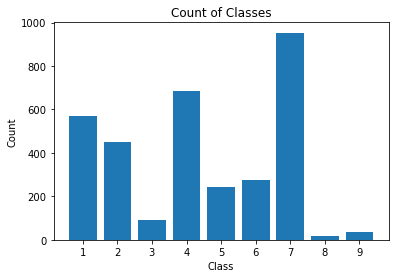

```python
barchart= plt.bar(classes, counts)
plt.title('Count of Classes')
plt.xlabel("Class")
plt.ylabel("Count")
```

**Heat Map**

The following map shows the correlation between two variables. Since correlation is a measure of the linear relationship between these variables, we can assume there is little to no linear relationships between any two variables.

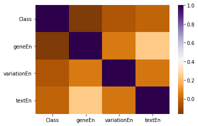

```python
correlation= dataEncoding.corr()
sns.heatmap(correlation, cmap='PuOr')
```

**Pivot Table**

The following table is able to display different relationships between the variables.

```python
pivot_ui(dataEncoding)
```

[interactive chart not shown]

## Model 1: Decision Tree

Splits data into nodes and subnodes based on similarities in gene, variation, and text in order to predict the class of the genetic mutation.

[figure not shown]

https://venngage.com/blog/what-is-a-decision-tree/

**The Decision Tree Model for this data yields approximately a 55% accuracy rating of predicting the class of genetic mutation (from 1-9).**

**Decision Tree Model Code:**

```python
#MODEL 1 IS THE DECISION TREE MODEL
from sklearn.tree import DecisionTreeClassifier
model1= DecisionTreeClassifier()

#have the model fit out train data
model1.fit(inputTrain, outputTrain)

#have the model make predictions based off our test input
predictions1=model1.predict(inputTest)

#see how accurate our predictions of test are by comparing with the test output
from sklearn.metrics import accuracy_score
score1= accuracy_score(outputTest, predictions1) #relationship between predictions and outputTest

#display the score
score1
```

```
0.5428571428571428
```

### Model 2: Single Value Decomposition (SVD)

SVD takes our data frame matrix and splits it into 3 smaller matrices (U, Sigma, V^T) that when multiplied obtain the original matrix. These matrices are generated from the data's latent features and the strength of these latent features. SVD is useful in dimensionality reduction.

[figure not shown]

https://towardsdatascience.com/understanding-singular-value-decomposition-and-its-application-in-data-science-388a54be95d

**SVD Model Code**

```python
from surprise import SVD

#create a reader, and the range of classes 1-9
reader= Reader(rating_scale= (1,9))

#SVD can only have three columns with class listed last, create entire SVD data
svdData=dataEncoding[["geneEn", 'variationEn', 'Class']]

#create the data for the model using the reader
svd=Dataset.load_from_df(svdData, reader)

#split the data into train and test sets
svdTrain, svdTest= train_test_split(svd, test_size=.2)

#create SVD model with 100 latent features(common number to use)
model= SVD(n_factors=50)

#fit the model to the svd training data
model.fit(svdTrain)
```

```
<surprise.prediction_algorithms.matrix_factorization.SVD at 0x7fc95e664310>
```

**SVD Code Continued**

```python
#determine the length of the test set
length= len(svdTest)

#create an array of the test set class answers
answers=[]
i=0
while i<=length-1:
    answers.append(svdTest[i][2])
    i=i+1
```

```python
#create an array of the class predictions from the svd test set
predictions=[]
i=0
while i<=length-1:
    #round the predictions to the nearest class
    predictions.append(round(testing[i][3]))
    i=i+1
```

**The SVD Model for this data yields a 10-20% accuracy rating on predicting the class of genetic mutation.**

SVD works best when there are more columns and fewer rows for dimensionality reduction. Since this data has many rows and few columns this could be the reason for this model's low success.

```python
#determine the accuracy between the class answers and class predictions from the svd model
score=accuracy_score(predictions, answers)
print(score)
```

```
0.1849624060150376
```

### Model 3: Random Forest

Similiar to Decision Tree, but random forest builds multiple decision trees and then merges them together.

[figure not shown]

https://www.analyticsvidhya.com/blog/2020/05/decision-tree-vs-random-forest-algorithm/

**Random Forest yields a 60% accuracy rating on predicting the class of genetic mutation.**

**Random Forest Model Code:**

```python
#use the trainInput, trainOutput, testInput, and testOutput data from model 1
model3=RandomForestClassifier(n_estimators=100)

#have the model fit the train data
model3.fit(inputTrain, outputTrain)

#have the model make predictions based off out test inputs
predictions3= model3.predict(inputTest)

#determine the accuracy of the predictions
score3= accuracy_score(outputTest, predictions3)

#print the score
score3
```

```
0.5864661654135338
```

### Model 4: Logistic Regression

Logistic Regression uses a statistical model to find the logarithmic relationship between the inputs and the class.

[figure not shown]

https://scipython.com/blog/logistic-regression-for-image-classification/

**Logistic Regression Model Code:**

```python
model4=LogisticRegression(solver='liblinear', random_state=0)

model4.fit(inputTrain, outputTrain)

intercept= model4.intercept_
b=model4.coef_

predictions4= model4.predict(inputTest)


score4=accuracy_score(predictions4, outputTest)

score4
```

```
0.3609022556390977
```

### K Nearest Neighbor

K Nearest Neighbor predicts the class by looking at the category of its nearest "neighbor" or closest data point.

[figure not shown]

https://www.analyticsvidhya.com/blog/2018/03/introduction-k-neighbours-algorithm-clustering/

**K Nearest Neighbor Model Code:**

```python
# k nearest neighbor
from sklearn.neighbors import NearestNeighbors
from sklearn.neighbors import KNeighborsClassifier

model5= KNeighborsClassifier(n_neighbors=1)

model5.fit(inputTrain, outputTrain)

predictions5= model5.predict(inputTest)

score5=accuracy_score(predictions5, outputTest)
score5
```

```
0.4270676691729323
```

# Summary of Results

### Random Forest provided the best model, while SVD and Logistic Regression performed the worst.

[figure not shown]

# How this Study Can be Furthered

- finding more models: whether it be applying a neural network model or separting the data even further and applying different models to subsets of data
- simplfying the text data even further: finding other ways to analyze its usefulness instead of just encoding it

# Challenges Throughout the Study

- analyzing the text data: having to separate, clean, merge, and encode before being able to apply the different models
- separting into train and test sets: had to use Jupyters train_test_split class due to the different counts of the classes
- finding a model that could be applied and worked for this data: since all gene/variation combos were unique, it is hard to train a set and then apply that model to a test set that has many differences

## Sources

Bagheri, Reza. (2020 January 9). *Understanding Singular Value Decomposition and Its Application in Data Science.* Towards Data Science. https://towardsdatascience.com/understanding-singular-value-decomposition-and-its- application-in-data-science-388a54be95d

Kaggle. (2017). *Personalized Medicine: Redefining Cancer Treatment.* https://www.kaggle.com/c/msk-redefining-cancer-treatment

*Logistic Regression for Image Classification.* (2020 September 3). https://scipython.com/blog/logistic-regression-for-image-classification/

Sharma, Abhishek. (2020 May 12). *Decision tree vs. Random Forest- Which Algorithm Should You Use?* Analytics Vidhya. https://www.analyticsvidhya.com/blog/2020/05/decision-tree-vs-random-forest-algorithm/

Sottoriva, Andrea. *Computational Biology.* Human Technopole. https://humantechnopole.it/en/research-centres/computational-biology/

Srivastava, Tavish. (2018 March 26). *Introduction to k-Nearest Neighbors: A Powerful Machine Learning Algorithm.* Analytics Vidhya. https://www.analyticsvidhya.com/blog/2018/03/introduction-k-neighbours-algorithm-clustering/